# obj_1

# Objectif 1

**Évaluer la performance de prédiction de la présence de végétation aquatique submergée dans les différents tronçons fluviaux du fleuve Saint-Laurent à l’aide des données RSI**

1. Modéliser statistiquement la relation entre la présence de VAS, la profondeur et la disponibilité en lumière pour les différents tronçons fluviaux du fleuve Saint-Laurent.
2. Évaluer l’importance de la variabilité physico-chimique / optique de l’eau dans la prédiction de la présence de VAS dans le cas du lac Saint-Pierre, via l’intégration des masses d’eau dans le modèle prédictif.

Cet objectif a été réalisé majoritairement dans le contexte du RIVE hacking 2024, à la maison Gault.

Équipe responsable: Arthur de Grandpré, Gilbert Cabana, Thibault Tournadre, avec contribution de Martin Laporte et Charles Martin

# Méthode

Modélistion statistique non linéaire des effets de la profondeur **(au zéro bathymétrique ou brute?)** et de la disponibilité en lumière (turbidité, ou Secchi) par modèles modèles linéaires généralisés (GLM) *et/ou additifs généralisés (GAM).*

Effets fixes: Profondeur, Secchi, Interaction Profondeur-Secchi

Effets aléatoires: Années, Secteurs, Masse d’eau

# Analyse

Charger les packages

Préparer les données pour l’analyse des secteurs visés, et création d’une variable présence/absence binaire.

1. Modéliser statistiquement la relation entre la présence de VAS, la profondeur et la disponibilité en lumière pour les différents tronçons fluviaux du fleuve Saint-Laurent.

Visualisation des effets individuels

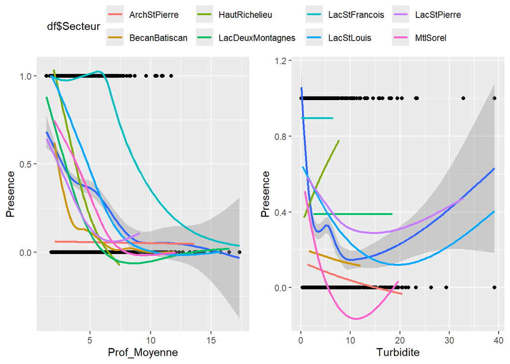

```r
gg_prof = df %>%
  ggplot(aes(x=Prof_Moyenne, y=Presence))+
  geom_point()+
  geom_smooth(method = "gam", se=T)+
  geom_smooth(method = "gam", se=F, aes(col=df$Secteur))

gg_turbi = df %>%
  ggplot(aes(x=Turbidite, y=Presence))+
  geom_point()+
  geom_smooth(method = "gam", se=T)+
  geom_smooth(method = "gam", se=F, aes(col=df$Secteur))

ggpubr::ggarrange(gg_prof, gg_turbi, common.legend = T)
```

Bien que l’effet de la profondeur soit évident, avec un intercept fort variable, les effets de la turbidité sont plus difficiles à visualiser comme tel.

Modélisation des effets; glmer

```r
fit_1 = glmer(
  Presence ~ Turbidite + Prof_Moyenne + (1|Annee) + (1|Secteur),
            data = df,
            family = binomial)

fit_1_interaction = glmer(
  Presence ~ Turbidite * Prof_Moyenne + (1|Annee) + (1|Secteur),
            data = df,
            family = binomial)

compare_performance(fit_1, fit_1_interaction)
```

```
# Comparison of Model Performance Indices

Name              |    Model |  AIC (weights) | AICc (weights) |  BIC (weights) | R2 (cond.) | R2 (marg.) |   ICC |  RMSE | Sigma | Log_loss | Score_log | Score_spherical
--------------------------------------------------------------------------------------------------------------------------------------------------------------------------
fit_1             | glmerMod | 1887.7 (0.728) | 1887.7 (0.729) | 1916.6 (0.980) |      0.707 |      0.373 | 0.532 | 0.347 | 1.000 |    0.378 |      -Inf |           0.004
fit_1_interaction | glmerMod | 1889.7 (0.272) | 1889.7 (0.271) | 1924.3 (0.020) |      0.707 |      0.377 | 0.529 | 0.347 | 1.000 |    0.378 |      -Inf |           0.004
```

Résulte en une sélection du modèle sans intéraction. Le faible R2 marginal suggère un effet important des facteurs aléatoires (Année et Secteur)

```r
summary(fit_1)
```

```
Generalized linear mixed model fit by maximum likelihood (Laplace
  Approximation) [glmerMod]
 Family: binomial  ( logit )
Formula: Presence ~ Turbidite + Prof_Moyenne + (1 | Annee) + (1 | Secteur)
   Data: df

     AIC      BIC   logLik deviance df.resid
  1887.7   1916.6   -938.8   1877.7     2373

Scaled residuals:
     Min       1Q   Median       3Q      Max
-13.3735  -0.4820  -0.1063   0.3985  14.0609

Random effects:
 Groups  Name        Variance Std.Dev.
 Annee   (Intercept) 0.9898   0.9949
 Secteur (Intercept) 2.7538   1.6595
Number of obs: 2378, groups:  Annee, 16; Secteur, 8

Fixed effects:
             Estimate Std. Error z value Pr(>|z|)
(Intercept)   3.87009    0.70671   5.476 4.34e-08 ***
Turbidite    -0.16838    0.02039  -8.257  < 2e-16 ***
Prof_Moyenne -0.84901    0.05305 -16.005  < 2e-16 ***
---
Signif. codes:  0 '***' 0.001 '**' 0.01 '*' 0.05 '.' 0.1 ' ' 1

Correlation of Fixed Effects:
            (Intr) Turbdt
Turbidite   -0.177
Prof_Moyenn -0.329  0.191
```

Les deux effets fixes sont considérés significatifs.

Comparaison des secteurs

```r
fit_s1 = glmer(
  Presence ~ Turbidite + Prof_Moyenne + (1|Annee),
            data = filter(df, Secteur == "ArchStPierre"),
            family = binomial)

fit_s2 = glmer(
  Presence ~ Turbidite + Prof_Moyenne + (1|Annee),
            data = filter(df, Secteur == "LacStFrancois"),
            family = binomial)

fit_s3 = glmer(
  Presence ~ Turbidite + Prof_Moyenne + (1|Annee),
            data = filter(df, Secteur == "LacStLouis"),
            family = binomial)

fit_s4 = glmer(
  Presence ~ Turbidite + Prof_Moyenne + (1|Annee),
            data = filter(df, Secteur == "LacStPierre"),
            family = binomial)

fit_s5 = glmer(
  Presence ~ Turbidite + Prof_Moyenne + (1|Annee),
            data = filter(df, Secteur == "BecanBatiscan"),
            family = binomial)

fit_s6 = glmer(
  Presence ~ Turbidite + Prof_Moyenne + (1|Annee),
            data = filter(df, Secteur == "MtlSorel"),
            family = binomial)

fit_s7 = glm( # sans effet aléatoire car une seule année disponible
  Presence ~ Turbidite + Prof_Moyenne,
            data = filter(df, Secteur == "HautRichelieu"),
            family = binomial)

fit_s8 = glm( # sans effet aléatoire car une seule année disponible
  Presence ~ Turbidite + Prof_Moyenne,
            data = filter(df, Secteur == "LacDeuxMontagnes"),
            family = binomial)

scoretab = compare_performance(fit_s1, fit_s2, fit_s3, fit_s4, fit_s5, fit_s6, fit_s7, fit_s8)
```

```
Random effect variances not available. Returned R2 does not account for random effects.
```

```r
# produire un tableau qui compile les coefficient et différents r2 par secteur
secteur_summary = tibble(
  Secteur = c("ArchStPierre", "LacStFrancois", "LacStLouis",
              "LacStPierre", "BecanBatiscan", "MtlSorel",
              "HautRichelieu", "LacDeuxMontagnes"),
  Intercept = c(summary(fit_s1)$coefficients[1,1], summary(fit_s2)$coefficients[1,1],
                summary(fit_s3)$coefficients[1,1], summary(fit_s4)$coefficients[1,1],
                summary(fit_s5)$coefficients[1,1], summary(fit_s6)$coefficients[1,1],
                summary(fit_s7)$coefficients[1,1], summary(fit_s8)$coefficients[1,1]),
  Turbidite = c(summary(fit_s1)$coefficients[2,1], summary(fit_s2)$coefficients[2,1],
                summary(fit_s3)$coefficients[2,1], summary(fit_s4)$coefficients[2,1],
                summary(fit_s5)$coefficients[2,1], summary(fit_s6)$coefficients[2,1],
                summary(fit_s7)$coefficients[2,1], summary(fit_s8)$coefficients[2,1]),
  Profondeur = c(summary(fit_s1)$coefficients[3,1], summary(fit_s2)$coefficients[3,1],
                summary(fit_s3)$coefficients[3,1], summary(fit_s4)$coefficients[3,1],
                summary(fit_s5)$coefficients[3,1], summary(fit_s6)$coefficients[3,1],
                summary(fit_s7)$coefficients[3,1], summary(fit_s8)$coefficients[3,1]),
  R2.cond = scoretab$R2_conditional,
  R2.marg = scoretab$R2_marginal,
  R2 = scoretab$R2_Tjur
)

secteur_summary %>% gt::gt() %>% gt::fmt_number(decimals = 2)
```

| Secteur | Intercept | Turbidite | Profondeur | R2.cond | R2.marg | R2 |
| --- | --- | --- | --- | --- | --- | --- |
| ArchStPierre | 0.88 | −0.30 | −0.36 | 0.35 | 0.30 | NA |
| LacStFrancois | 8.17 | −0.23 | −0.84 | NA | 0.57 | NA |
| LacStLouis | 5.09 | −0.10 | −1.10 | 0.75 | 0.74 | NA |
| LacStPierre | 2.42 | −0.13 | −0.68 | 0.26 | 0.18 | NA |
| BecanBatiscan | 2.17 | −0.14 | −0.83 | 0.67 | 0.50 | NA |
| MtlSorel | 5.43 | −0.89 | −1.02 | 0.80 | 0.78 | NA |
| HautRichelieu | 9.20 | −0.28 | −2.28 | NA | NA | 0.55 |
| LacDeuxMontagnes | 8.55 | −0.44 | −2.26 | NA | NA | 0.49 |

Les résultats suggèrent une variabilité importante entre les secteurs, avec des performances predictives beaucoup plus faibles dans les secteurs de l’archipelle du Lac Saint-Pierre et du Lac Saint-Pierre; le tronçon le moins profond, le plus turbide, mais aussi le plus contrasté spatiotemporellement (masses d’eau, innondations).

2. Évaluer l’importance de la variabilité physico-chimique / optique de l’eau dans la prédiction de la présence de VAS dans le cas du lac Saint-Pierre, via l’intégration des masses d’eau dans le modèle prédictif.

Séparation des masses d’eau

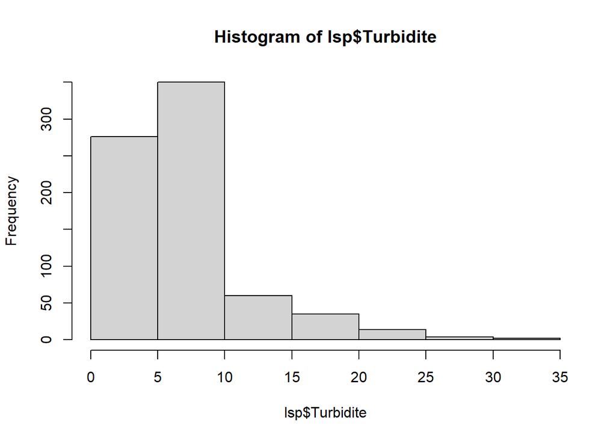

```r
lsp = df %>% filter(Secteur %in% c("LacStPierre"))

hist(lsp$Turbidite)
```

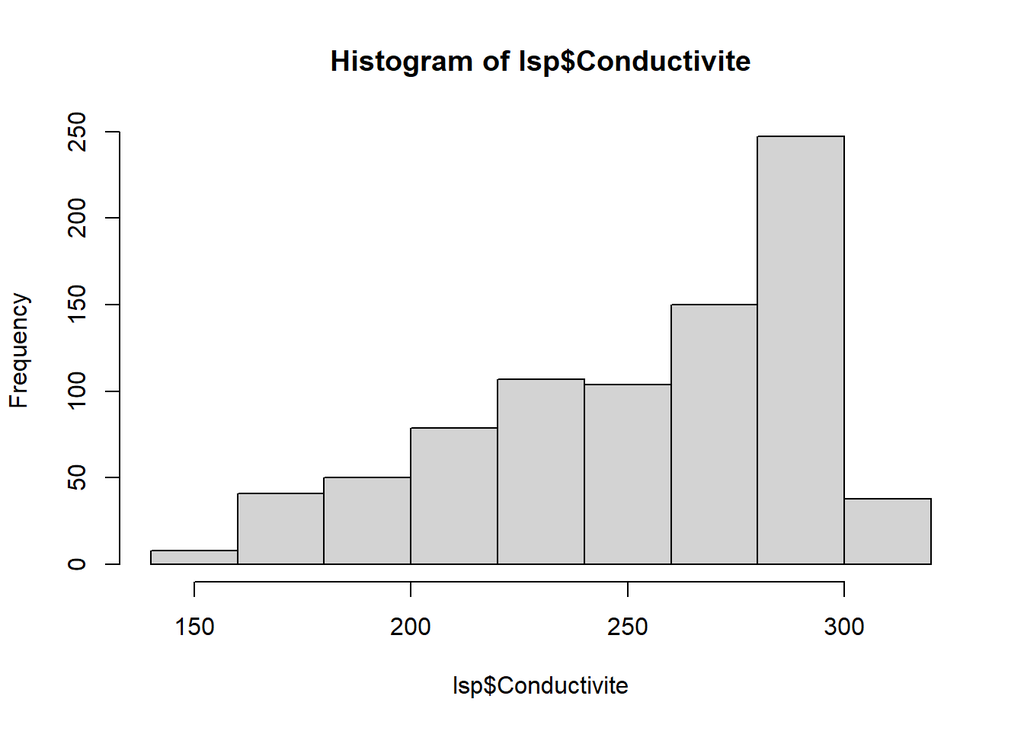

```r
hist(lsp$Conductivite)
```

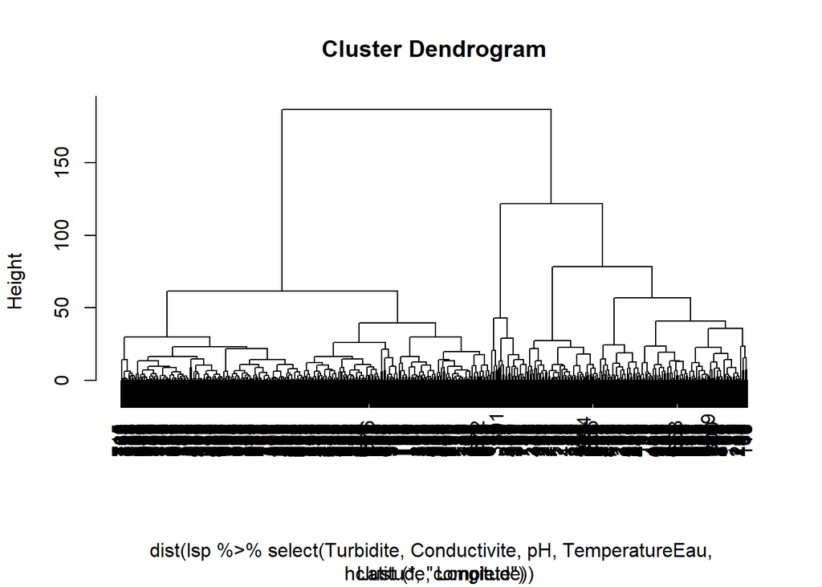

```r
hc = hclust(dist(lsp %>% select(Turbidite, Conductivite, pH, TemperatureEau, Latitude, Longitude)))
plot(hc)
```

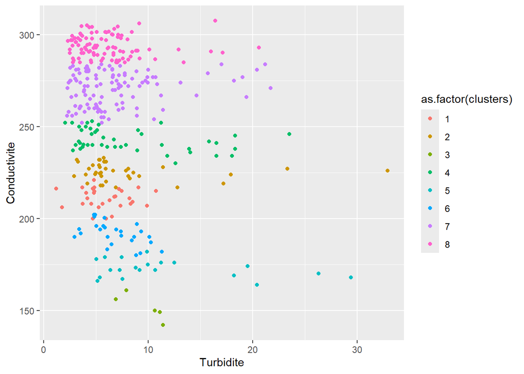

```r
clusters = cutree(hc, k=8)

lsp %>%
  ungroup() %>%
  mutate(clusters = clusters) %>%
  ggplot(aes(x=Turbidite, y=Conductivite, col=as.factor(clusters)))+
  geom_point()
```

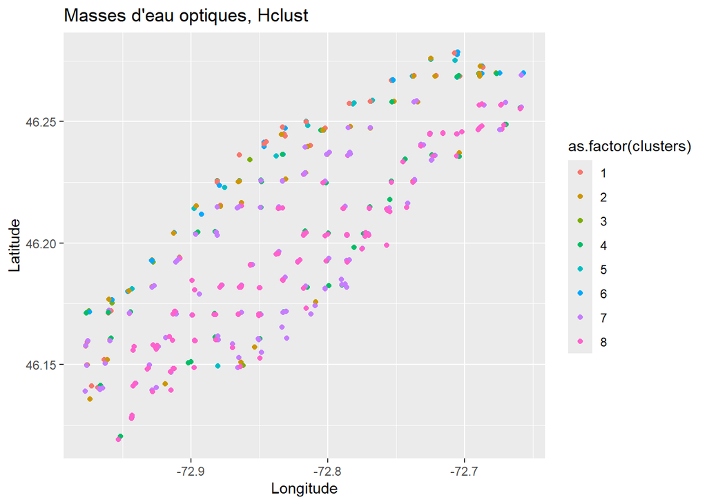

```r
lsp %>%
  ggplot(aes(x=Longitude, y=Latitude, col=as.factor(clusters)))+
  geom_point()+
  ggtitle("Masses d'eau optiques, Hclust")
```

```r
table(clusters)
```

```
clusters
  1   2   3   4   5   6   7   8
 63  78  10  94  39  54 246 240
```